# Problem Set 2: Fundamentals of Statistics

Heatherlee Leary

2023-02-09

## **Question 1**

#### A researcher videotaped the glides of 8 tree snakes leaping from a 10-m tower. Undulation rates of the snakes measured in hertz (cycles per second) were as follows: 0.9, 1.4, 1.2, 1.2, 1.3, 2.0, 1.4, 1.6.

#### a) Draw a histogram of the undulation rate

#### b) Calculate the sample mean

#### d) Calculate the standard deviation

#### e) Write a function to express the standard deviation as a percentage of the mean (that is, the coefficient of variation) and calculate it.

```r
# Load libraries
library(tidyverse)
```

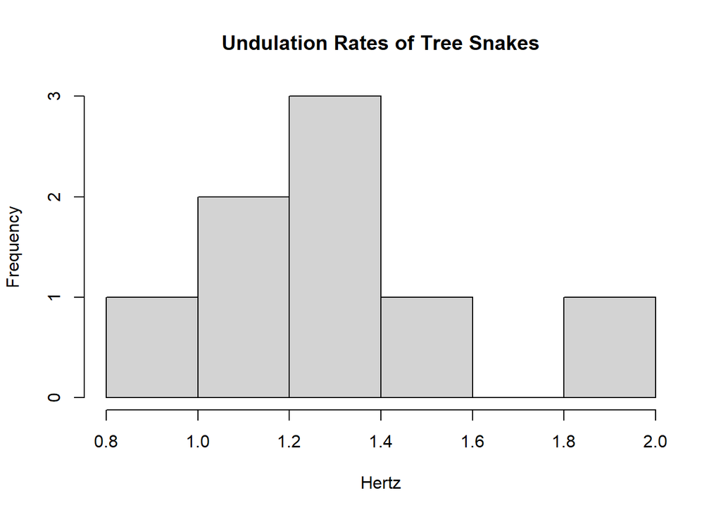

```r
library(ggplot2)

# Put rates into a vector
und_rates <- c(0.9, 1.4, 1.2, 1.2, 1.3, 2.0, 1.4, 1.6)


# Draw histogram
hist(und_rates, xlab = "Hertz", ylab = "Frequency", main = "Undulation Rates of Tree Snakes")
```

```r
# Calculate sample mean
mean(und_rates)
```

```
## [1] 1.375
```

```r
# Calculate range
range(und_rates)
```

```
## [1] 0.9 2.0
```

```r
# Calculate standard deviation
sd(und_rates)
```

```
## [1] 0.324037
```

```r
# Write a function to express the standard deviation
# as a percentage of the mean (that is, the coefficient of variation (CV)) and calculate it.
coef_var <- function(x) {
  sd(x) / mean(x) * 100
}
coef_var(und_rates)
```

```
## [1] 23.56633
```

## **Question 2**

#### Blood pressure was measured (in units of mm Hg). Here are the measurements: 112, 128, 108, 129, 125, 153, 155, 132, 137.

#### a) How many individuals are in the sample?

#### b) What is the mean of this sample?

#### d) What is the standard deviation?

#### e) What is the coefficient of variation?

```r
# Assign blood pressure measurements (bp) to a vector
bp <- c(112, 128, 108, 129, 125, 153, 155, 132, 137)

# a) How many individuals are in the sample?
length(bp)
```

```
## [1] 9
```

```r
# b) What is the mean of this sample?
mean(bp)
```

```
## [1] 131
```

```r
# c) What is the variance?
var(bp)
```

```
## [1] 254.5
```

```r
# d) What is the standard deviation?
sd(bp)
```

```
## [1] 15.95306
```

```r
# e) What is the coefficient of variation?
coef_var <- function(x) {
  sd(x) / mean(x) * 100
}
coef_var(bp)
```

```
## [1] 12.17791
```

## **Problem 3**

#### The data in the file DesertBirdAbundance.csv are from a survey of the breeding birds of Organ Pipe Cactus National Monument in southern Arizona.

#### a) Draw a histogram of the abundance data.

#### b) Calculate the median and the mean of the bird abundance data.

#### c) In this particular case, which do you think is the best measure of center, the mean or the median?

#### d) Calculate the range, standard deviation, variance and coefficient of variation of the bird abundance data.

```r
# Read in the Desert Bird Abundance csv file.
birdset <- read.csv(file = "C:\\Users\\hlear\\Desktop\\statsandviz\\R02_fundamentals_statistics\\data\\DesertBirdAbundance.csv", header = TRUE)

# Explore
head(birdset)
```

```
##            species abundance
## 1    Black Vulture        64
## 2   Turkey Vulture        23
## 3    Harris's Hawk         3
## 4  Red-tailed Hawk        16
## 5 American Kestrel         7
## 6   Gambel's Quail       148
```

```r
class(birdset)
```

```
## [1] "data.frame"
```

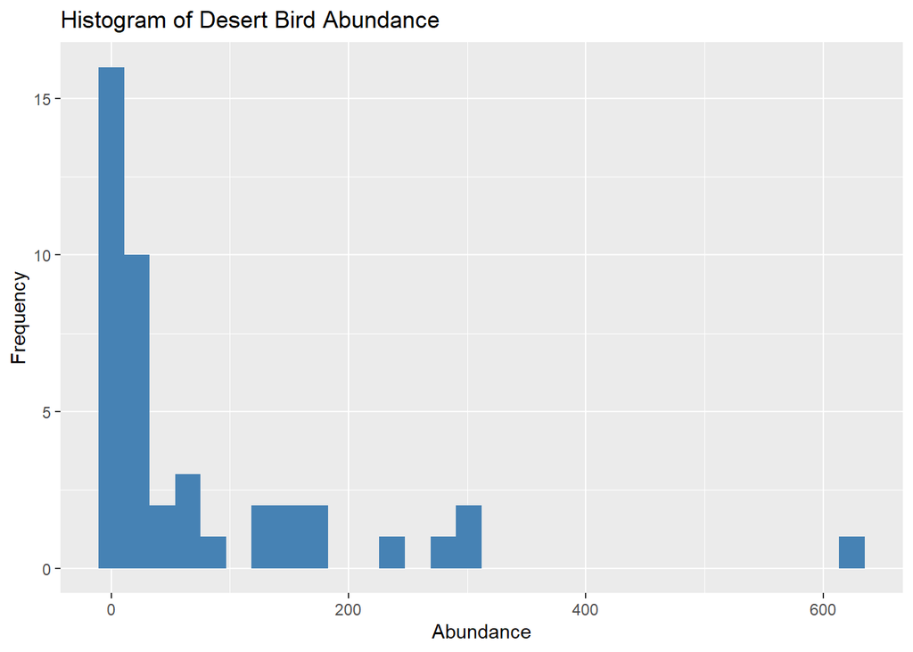

```r
# a) Histogram using ggplot2
ggplot(birdset, aes(x=abundance))+
  geom_histogram(fill = "steelblue") +
  labs(title = "Histogram of Desert Bird Abundance", x = "Abundance", y = "Frequency")
```

```r
# b) Median and Mean
mean(birdset$abundance)
```

```
## [1] 74.76744
```

```r
median(birdset$abundance)
```

```
## [1] 18
```

```r
# c) Best measure of center in this case?
# The median

# d) Range, SD, variance, and CV
range(birdset$abundance)
```

```
## [1]   1 625
```

```r
sd(birdset$abundance)
```

```
## [1] 121.9473
```

```r
var(birdset$abundance)
```

```
## [1] 14871.14
```

```r
coef_var <- function(x) {
  sd(x) / mean(x) * 100
}
coef_var(birdset$abundance)
```

```
## [1] 163.1021
```

## **Problem 4**

#### Calculate the probability of each of the following events:

#### a) A standard normally distributed variable is larger than 3

#### b) A normally distributed variable with mean 35 and standard deviation 6 is larger than 42

#### c) Getting 10 out of 10 successes in a binomial distribution with probability 0.8

#### d) X > 6.5 in a Chi-squared distribution with 2 degrees of freedom

```r
# a) A standard normally distributed variable is larger than 3
pnorm(3, lower.tail = FALSE)
```

```
## [1] 0.001349898
```

```r
# b) A normally distributed variable with mean 35 and standard deviation 6 is larger than 42
pnorm(42, mean = 35, sd = 6, lower.tail = FALSE)
```

```
## [1] 0.1216725
```

```r
# c) Getting 10 out of 10 successes in a binomial distribution with probability 0.8
dbinom(10, size = 10, prob = 0.8) # dbinom instead of pbinom because it's a discrete probability, we're not integrating anything.
```

```
## [1] 0.1073742
```

```r
# d) X > 6.5 in a Chi-squared distribution with 2 degrees of freedom
pchisq(6.5, df = 2, lower.tail = FALSE)
```

```
## [1] 0.03877421
```

## **Problem 5**

#### Demonstrate graphically the central limit theorem (by sampling and calculating the mean) using a Binomial distribution with 10 trials (size=10) and 0.9 probability of success (prob=0.9) and a sample size of 5.

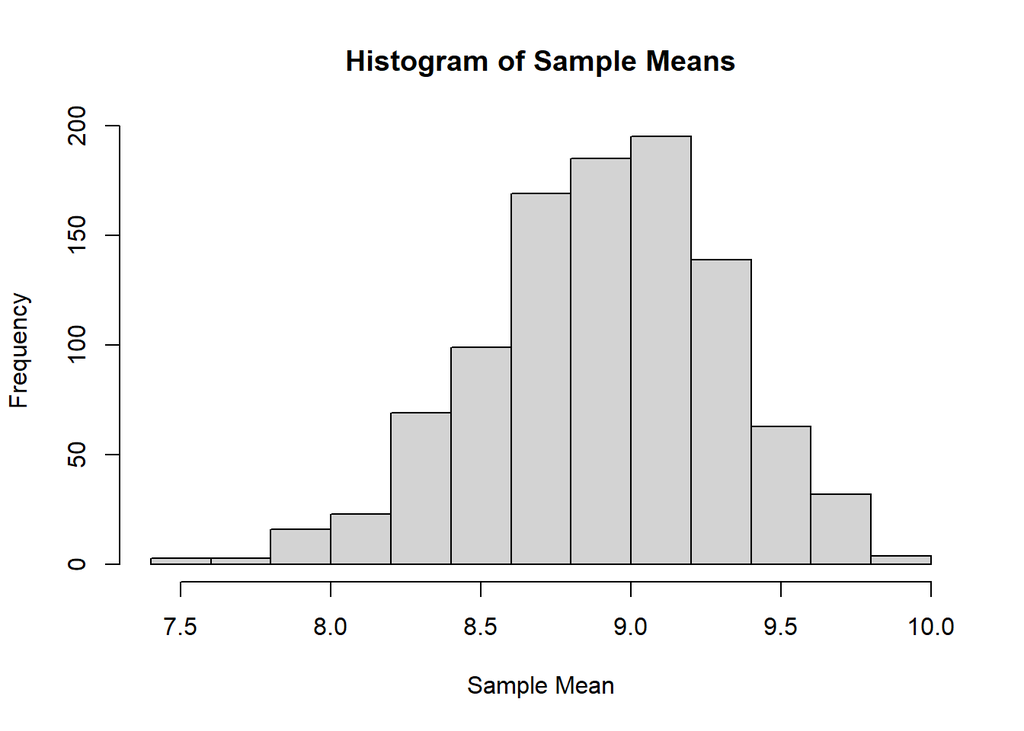

```r
# Create a vector to store the mean of each sample
means <- numeric(1000)

# Loop to generate 1000 samples of size 5 from the Binomial distribution
for (i in 1:1000) {
  sample <- rbinom(5, size= 10, prob= 0.9) # generate sample of size 5
  means[i] <- mean(sample) # calculate mean of the sample
}

# Plot the histogram of the sample means
hist(means, main = "Histogram of Sample Means", xlab = "Sample Mean")
```